# Desmognathus cheaha presence/absence models

Nick Chang

2025-03-21

```r
#set wd
setwd("~/Downloads/GitHub/desmog-cheaha-microhabitat-2025/code")

# importing band-level data
bands = read.csv("../data/bands_2025-01-29.csv")
# importing plot-level data
plots = read.csv("../data/plots_2025-01-29.csv")
# importing data about individual organisms
points = read.csv("../data/points_2025-01-29.csv")
# importing data about capture points (by rock instead of by salamander)
pointsWide = read.csv("../data/pointsWide_2024-12-22.csv")

# Creating a vector of seal salamander streams that we can use to filter later
sealStreams = c("STRM07", "STRM06", "STRM10", "STRM01", "STRM04", "STRM08", "STRM02")


#creating a subset of bands that are from streams that had seal salamanders
ssBands = bands %>% filter(StrmID %in% sealStreams)

#creating a color palette
cols = c(
        'PSRUB' = "#C95945",
         "ECIR" = "#E6BC52",
         'EGUT' = '#E68E1C',
         "DCHE" = "#5D695C",
          #"DCHE" = "#70665e",
          "DPER" = "#81705c",
          #'DPER' = '#AFA060',
         'CAM' = "#c7a891",
        'VAC' = "#90AA86"
         )

colsBi = c('1' = "#5D695C",
           '0' = "#90AA86")
```

# Introduction

This markdown file contains analyses for my Honors Thesis on the Talladega seal salamander (*Desmognathus cheaha*) which I have conducted after consultation with my Thesis committee on November 27th, 2023.

At the microhabitat scale, I am interested in what factors predict microhabitat selection by seal salamanders, particularly whether they are actively selecting different cover objects.

- For this dataset, I will be evaluating using binomial presence/absence models because while there were a few rocks that had multiple seal salamanders under them, that number was very low.
- I will be filtering my data to only be for streams that have seals in them, because I have reason to suspect that there are water quality parameters influencing the presence/absence of seal salamanders (notably, temperature variation)
- I will also be filtering my data to only include observations that were underneath rocks or wood. Two observations of seal salamanders were in burrows, which differ fundamentally in terms of microhabitat. In addition, we are dropping observations from leafpacks and individuals in the open because there were none of these observations with seal salamanders.
- I will be running logistic regressions where:
  - 1 = seal salamander
  - 0 = no seal salamander BUT may contain other salamanders or crayfish

## Microhabitat data transformation

I need to make a few changes to the dataset to perform these analyses. Below, I am going to:  
* create a `rocky` substrate composite by adding the percent cover of gravel and rock. * create a binary response variable of points that have seals or are completely vacant (not going to end up using this but leaving it in the dataset in case it’s useful). * Creating a binary response variable to compare places with seal salamanders to places with other salamanders. * Creating a binary response variable that compares places that had any salamander to ones that were vacant

In addition, I am creating a subset of the data (`pWS`) which filters the microhabitat dataset so that my analyses are only include points from streams where we know that seal salamanders occur. This is because we believe there are likely some water quality parameters affecting the ability of other streams to support seal salamanders (see plotwise models), and that there are likely suitable cover items in these streams that don’t have seals because the habitat isn’t suitable for other reasons.  
I am also filtering to only include observations where the cover type was rock or wood, because there are some observations of seals in burrows and I feel that the substrate data isn’t comparable.

```r
pointsWide = pointsWide %>%

  #creating a composite of rocky substrate
  mutate(rocky = per_grav + per_rock) %>%

  #creating a response variable for seal vs. fully vacant points
  mutate(sealVac = NA) %>%
  mutate(sealVac = ifelse(Occupied == 0, 0, sealVac)) %>%
  mutate(sealVac = ifelse(DCHE != 0, 1, sealVac)) %>%

  #creating a response variable to compare seals vs. other salamanders
  mutate(sealSal = NA) %>%
  mutate(sealSal = ifelse(salCount > 0, 0, sealSal)) %>%
  mutate(sealSal = ifelse(DCHE != 0, 1, sealSal)) %>%

  #creating a response variable for the presence of dusky salamanders
  mutate(duskPres = ifelse(DPER >0, 1, 0)) %>%

  #creating a response variable for the presence of 2-lined salamanders
  mutate(cirrPres = ifelse(ECIR > 0, 1, 0 )) %>%

  #creating a respnse variable to compare sal vs. non-sal points
  mutate(salVac = ifelse(salCount > 0 & crayCount == 0, 1, 0)) %>%

  mutate(nonsealSalCount = SAL + ECIR + DPER +PSRUB + D + EGUT,
         nonsealOccCount = occupantCount-DCHE) %>%
  mutate(roommate = ifelse(nonsealOccCount >=1, "roommate", "no roommate")) %>%
  mutate(sealStream = ifelse(StrmID %in% c(sealStreams), 1, 0))
```

### Dealing with stream distance

*Sorting things by terrestrial/margin/stream* We are going to create a categorical variable that sorts salamanders into a terrestrial/margin/stream variable based on where they were found in/around the stream. Here, we are going to create some rules that say:

- Any point with a water depth of 1cm or less AND anything wthin 50cm of water is on the margin
- Anything with a distance to water greater than 50cm is considered terrestrial
- Anything with a deeper water depth is considered in the stream

50cm is considered the cutoff for terrestrial vs. marginal habitat because when we do our band-level quadrats for marginal habitat we try to center them on the edge of the stream with 50cm in the stream and 50cm out.

In addition, we are going to create a distDepth variable that combines the stream distance and water depth variables by subtracting depth from distance to water so that depth is a negative value.

```r
pointsWide = pointsWide %>%
  mutate(hab = ifelse(distWater > 50, "terrestrial", NA)) %>%
  mutate(hab = ifelse(cmDepth > 1, "stream", hab)) %>%
  mutate(hab = ifelse(is.na(hab) == T, "margin", hab)) %>%
  mutate(hab = as.factor(hab)) %>%
  mutate(distDepth = distWater - cmDepth)
# I am going to create a color palette to make this easier to interpret
habCols = c("stream" = "#9BC4BC", "margin" = "#4B5043", "terrestrial" = "#598218")
```

## Filtering to seal streams

```r
#filtering pointsWide to only include points from streams where seal salamanders are present
pWS = pointsWide %>%
  filter(StrmID %in% sealStreams) %>%
         #filtering to only include observations that were under rock or wood
  filter(CoverType %in% c("R", "W"))

# pointsWide %>%
#   filter(StrmID %in% sealStreams) %>%
#   group_by(CoverType) %>%
#   summarize(count = n())


# pWS %>% group_by(sealPres) %>% summarize(count = n())
```

## Fitting a null model

This is how I figured out how to get the marginal/conditional r2: https://github.com/glmmTMB/glmmTMB/issues/169

```r
mic_0 = glmmTMB(sealPres ~ (1|StrmID), data = pWS, family = "binomial")
summary(mic_0)
```

```
##  Family: binomial  ( logit )
## Formula:          sealPres ~ (1 | StrmID)
## Data: pWS
##
##      AIC      BIC   logLik deviance df.resid
##    180.9    187.9    -88.4    176.9      246
##
## Random effects:
##
## Conditional model:
##  Groups Name        Variance Std.Dev.
##  StrmID (Intercept) 0.582    0.7629
## Number of obs: 248, groups:  StrmID, 7
##
## Conditional model:
##             Estimate Std. Error z value Pr(>|z|)
## (Intercept)  -2.1535     0.3747  -5.747 9.06e-09 ***
## ---
## Signif. codes:  0 '***' 0.001 '**' 0.01 '*' 0.05 '.' 0.1 ' ' 1
```

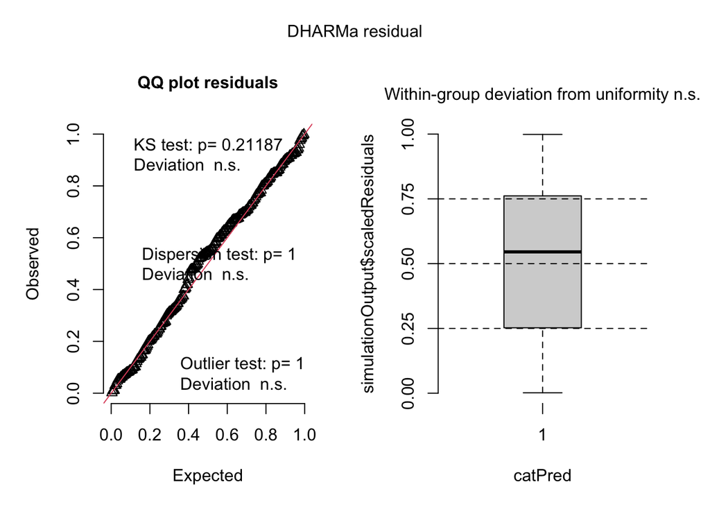

```r
resid_mic_0 = simulateResiduals(mic_0)
plot(resid_mic_0)
```

```r
tab_model(mic_0)
```

|  | sealPres |  |  |
| --- | --- | --- | --- |
| Predictors | Odds Ratios | CI | p |
| (Intercept) | 0.12 | 0.06 – 0.24 | **<0.001** |
| Random Effects |  |  |  |
| σ<sup>2</sup> | 3.29 |  |  |
| τ<sub>00</sub> <sub>StrmID</sub> | 0.58 |  |  |
| ICC | 0.15 |  |  |
| N <sub>StrmID</sub> | 7 |  |  |
| Observations | 248 |  |  |
| Marginal R<sup>2</sup> / Conditional R<sup>2</sup> | 0.000 / 0.150 |  |  |

```r
confint(mic_0)
```

```
##                                 2.5 %    97.5 %   Estimate
## (Intercept)                -2.8879400 -1.419157 -2.1535483
## Std.Dev.(Intercept)|StrmID  0.3164957  1.838939  0.7628999
```

```r
summary(mic_0)
```

```
##  Family: binomial  ( logit )
## Formula:          sealPres ~ (1 | StrmID)
## Data: pWS
##
##      AIC      BIC   logLik deviance df.resid
##    180.9    187.9    -88.4    176.9      246
##
## Random effects:
##
## Conditional model:
##  Groups Name        Variance Std.Dev.
##  StrmID (Intercept) 0.582    0.7629
## Number of obs: 248, groups:  StrmID, 7
##
## Conditional model:
##             Estimate Std. Error z value Pr(>|z|)
## (Intercept)  -2.1535     0.3747  -5.747 9.06e-09 ***
## ---
## Signif. codes:  0 '***' 0.001 '**' 0.01 '*' 0.05 '.' 0.1 ' ' 1
```

```r
exp(-2.1535)
```

```
## [1] 0.1160772
```

```r
performance::r2(mic_0)
```

```
## # R2 for Mixed Models
##
##   Conditional R2: 0.150
##      Marginal R2: 0.000
```

```r
AICc(mic_0)
```

```
## [1] 180.9067
```

# Microhabitat use by Seal Salamanders

## How does particle/pore space and the accumulation of sediment under cover objects affect presence/absence of seal salamanders?

sealPres ~ (%rock + %gravel) * hab + (1|StrmID), data = pWS

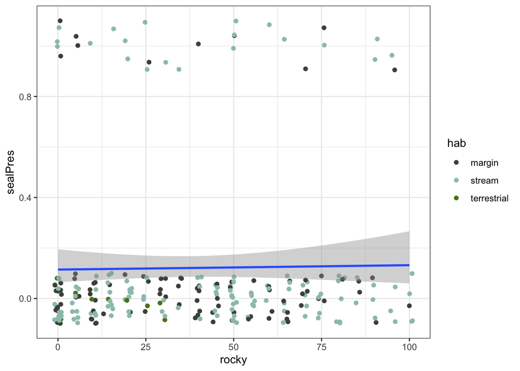

```r
pWS %>% ggplot(aes(x = rocky, y = sealPres)) +
  geom_jitter(aes(col = hab), height = .1) +
  scale_color_manual(values = habCols) +
  stat_smooth(method = "glm", method.args = list(family = "binomial")) +
  theme_bw()
```

```r
mic_1.1 = glmmTMB(sealPres ~ rocky + hab + (1|StrmID), data = pWS, family = "binomial")
summary(mic_1.1)
```

```
##  Family: binomial  ( logit )
## Formula:          sealPres ~ rocky + hab + (1 | StrmID)
## Data: pWS
##
##      AIC      BIC   logLik deviance df.resid
##    180.6    198.2    -85.3    170.6      243
##
## Random effects:
##
## Conditional model:
##  Groups Name        Variance Std.Dev.
##  StrmID (Intercept) 0.8266   0.9092
## Number of obs: 248, groups:  StrmID, 7
##
## Conditional model:
##                  Estimate Std. Error z value Pr(>|z|)
## (Intercept)    -2.661e+00  6.004e-01  -4.433 9.31e-06 ***
## rocky           2.273e-03  7.256e-03   0.313    0.754
## habstream       7.368e-01  4.569e-01   1.613    0.107
## habterrestrial -1.867e+01  1.015e+04  -0.002    0.999
## ---
## Signif. codes:  0 '***' 0.001 '**' 0.01 '*' 0.05 '.' 0.1 ' ' 1
```

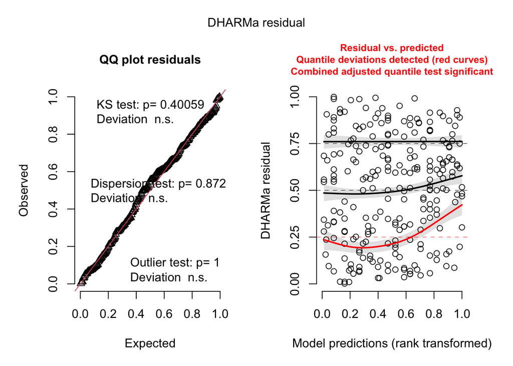

```r
resid_mic_1.1 = simulateResiduals(mic_1.1)
plot(resid_mic_1.1)
```

```r
tab_model(mic_1.1)
```

|  | sealPres |  |  |
| --- | --- | --- | --- |
| Predictors | Odds Ratios | CI | p |
| (Intercept) | 0.07 | 0.02 – 0.23 | **<0.001** |
| rocky | 1.00 | 0.99 – 1.02 | 0.754 |
| hab [stream] | 2.09 | 0.85 – 5.12 | 0.107 |
| hab [terrestrial] | 0.00 | 0.00 – Inf | 0.999 |
| Random Effects |  |  |  |
| σ<sup>2</sup> | 3.29 |  |  |
| τ<sub>00</sub> <sub>StrmID</sub> | 0.83 |  |  |
| ICC | 0.20 |  |  |
| N <sub>StrmID</sub> | 7 |  |  |
| Observations | 248 |  |  |
| Marginal R<sup>2</sup> / Conditional R<sup>2</sup> | 0.806 / 0.845 |  |  |

```r
confint(mic_1.1)
```

```
##                                    2.5 %        97.5 %      Estimate
## (Intercept)                -3.838066e+00 -1.484535e+00  -2.661300510
## rocky                      -1.194826e-02  1.649353e-02   0.002272634
## habstream                  -1.587441e-01  1.632288e+00   0.736771923
## habterrestrial             -1.990993e+04  1.987258e+04 -18.672576852
## Std.Dev.(Intercept)|StrmID  4.004624e-01  2.064167e+00   0.909187149
```

```r
AICc(mic_1.1)
```

```
## [1] 180.8928
```

```r
exp( -18.672576852)
```

```
## [1] 7.773255e-09
```

## How does the abundance of leaf litter affect cover object selection for seal salamanders?

I’m interested in whether salamanders are selecting rocks based on the presence of leaf litter surrounding them. There were a number of rocks that we found which served as physical infrastructure around which leaf packs were formed, and presumably the presence of leaf litter allows for places where salamanders are able to forage and find cover with a ton of new surface area to chill out in.

sealPres ~ (%litter) + (1|StrmID)

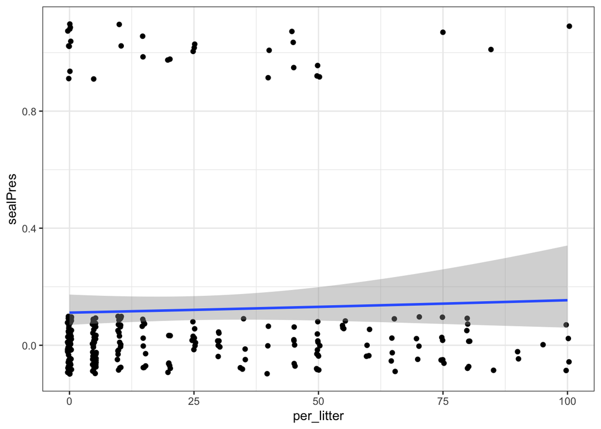

```r
pWS %>% ggplot(aes(x = per_litter, y = sealPres)) +
  geom_jitter( height = .1) +
  stat_smooth(method = "glm", method.args = list(family = "binomial")) +
  theme_bw()
```

```r
mic_2.1 = glmmTMB(sealPres ~ per_litter + (1|StrmID), data = pWS, family = "binomial")
summary(mic_2.1)
```

```
##  Family: binomial  ( logit )
## Formula:          sealPres ~ per_litter + (1 | StrmID)
## Data: pWS
##
##      AIC      BIC   logLik deviance df.resid
##    182.8    193.4    -88.4    176.8      245
##
## Random effects:
##
## Conditional model:
##  Groups Name        Variance Std.Dev.
##  StrmID (Intercept) 0.6047   0.7776
## Number of obs: 248, groups:  StrmID, 7
##
## Conditional model:
##              Estimate Std. Error z value Pr(>|z|)
## (Intercept) -2.116875   0.433319  -4.885 1.03e-06 ***
## per_litter  -0.001472   0.008526  -0.173    0.863
## ---
## Signif. codes:  0 '***' 0.001 '**' 0.01 '*' 0.05 '.' 0.1 ' ' 1
```

```r
AICc(mic_2.1)
```

```
## [1] 182.926
```

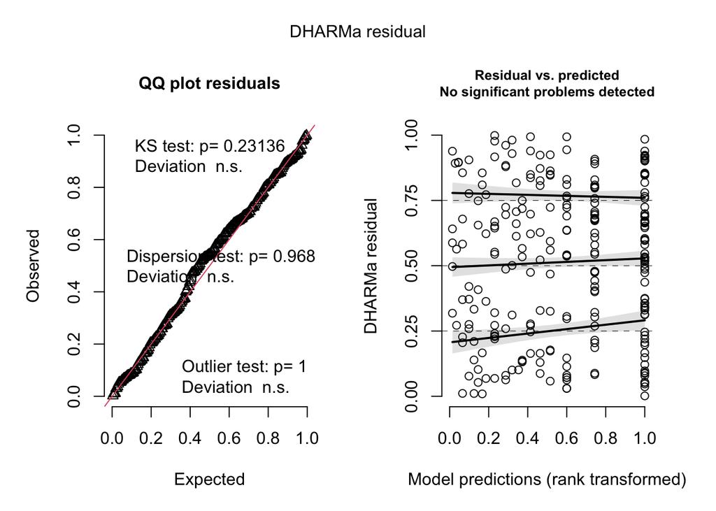

```r
resid_mic_2.1 = simulateResiduals(mic_2.1)
plot(resid_mic_2.1)
```

```r
tab_model(mic_2.1)
```

|  | sealPres |  |  |
| --- | --- | --- | --- |
| Predictors | Odds Ratios | CI | p |
| (Intercept) | 0.12 | 0.05 – 0.28 | **<0.001** |
| per litter | 1.00 | 0.98 – 1.02 | 0.863 |
| Random Effects |  |  |  |
| σ<sup>2</sup> | 3.29 |  |  |
| τ<sub>00</sub> <sub>StrmID</sub> | 0.60 |  |  |
| ICC | 0.16 |  |  |
| N <sub>StrmID</sub> | 7 |  |  |
| Observations | 248 |  |  |
| Marginal R<sup>2</sup> / Conditional R<sup>2</sup> | 0.000 / 0.156 |  |  |

```r
confint(mic_2.1)
```

```
##                                  2.5 %      97.5 %     Estimate
## (Intercept)                -2.96616430 -1.26758600 -2.116875150
## per_litter                 -0.01818264  0.01523926 -0.001471692
## Std.Dev.(Intercept)|StrmID  0.31679087  1.90885468  0.777629557
```

```r
#obtaining the conditional and marginal r2
performance::r2(mic_2.1)
```

```
## # R2 for Mixed Models
##
##   Conditional R2: 0.156
##      Marginal R2: 0.000
```

## How does the distribution of cover objects of various sizes in and around the stream affect the presence/absence of salamanders?

sealVac ~ coverObjArea * hab + (1|StrmID)

hab = stream, margin, terrestrial

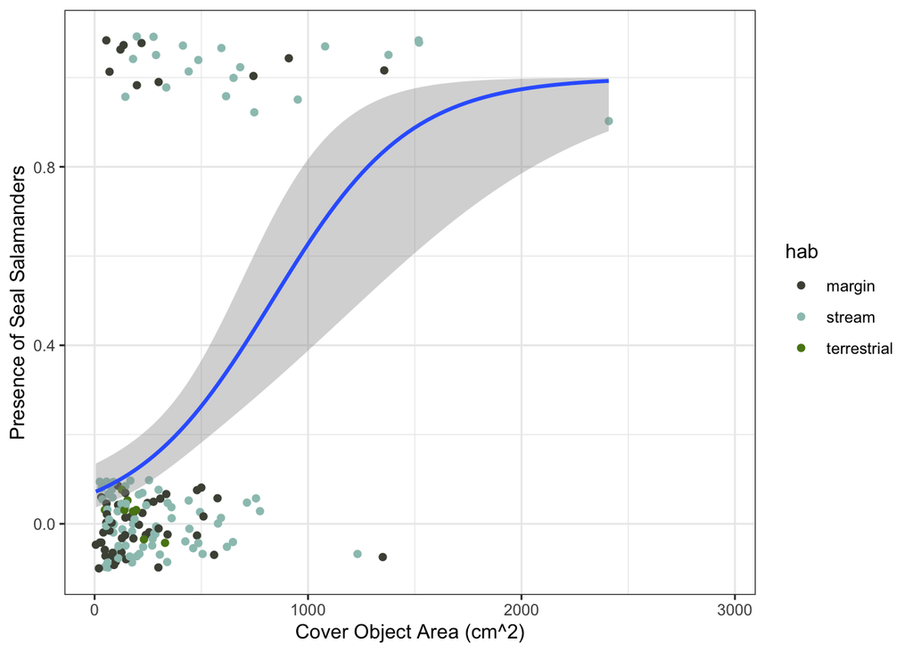

```r
pWS %>% ggplot(aes(x = covArea, y = sealVac)) +
  geom_jitter(aes(col = hab), height = .1) +
  xlab("Cover Object Area (cm^2)") +
  ylab("Presence of Seal Salamanders") +
  scale_color_manual(values = habCols) +
  stat_smooth(method = "glm", method.args = list(family = "binomial")) +
  theme_bw()
```

```r
mic_3.1 = glmmTMB(sealPres ~ covArea + hab + (1|StrmID), data = pWS, family = "binomial")
summary(mic_3.1)
```

```
##  Family: binomial  ( logit )
## Formula:          sealPres ~ covArea + hab + (1 | StrmID)
## Data: pWS
##
##      AIC      BIC   logLik deviance df.resid
##    172.1    189.7    -81.1    162.1      243
##
## Random effects:
##
## Conditional model:
##  Groups Name        Variance Std.Dev.
##  StrmID (Intercept) 0.8987   0.948
## Number of obs: 248, groups:  StrmID, 7
##
## Conditional model:
##                  Estimate Std. Error z value Pr(>|z|)
## (Intercept)    -3.089e+00  5.904e-01  -5.232 1.68e-07 ***
## covArea         1.183e-03  4.211e-04   2.808  0.00498 **
## habstream       6.775e-01  4.668e-01   1.451  0.14668
## habterrestrial -1.894e+01  1.084e+04  -0.002  0.99861
## ---
## Signif. codes:  0 '***' 0.001 '**' 0.01 '*' 0.05 '.' 0.1 ' ' 1
```

```r
AICc(mic_3.1)
```

```
## [1] 172.3949
```

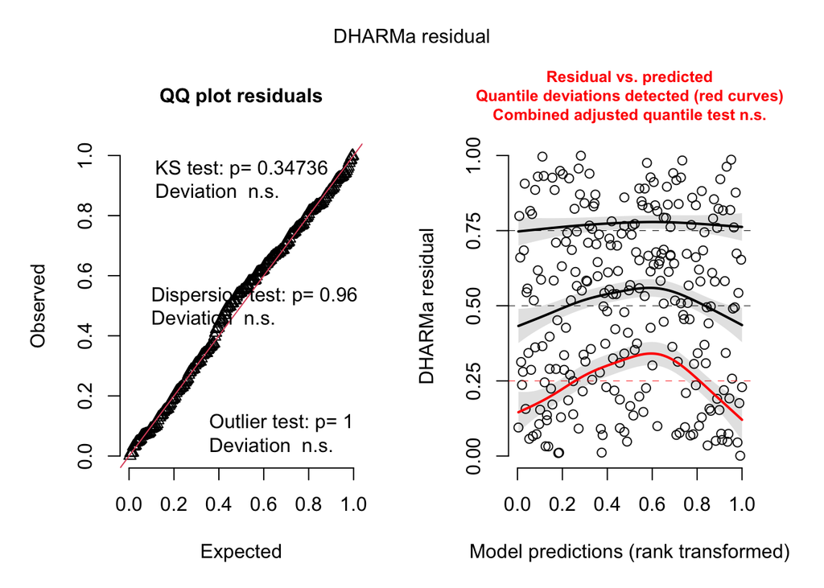

```r
resid_mic_3.1 = simulateResiduals(mic_3.1)
plot(resid_mic_3.1)
```

```r
confint(mic_3.1)
```

```
##                                    2.5 %        97.5 %      Estimate
## (Intercept)                -4.245758e+00 -1.931615e+00  -3.088686086
## covArea                     3.572743e-04  2.008142e-03   0.001182708
## habstream                  -2.374346e-01  1.592487e+00   0.677526104
## habterrestrial             -2.125792e+04  2.122004e+04 -18.940919551
## Std.Dev.(Intercept)|StrmID  4.137991e-01  2.171810e+00   0.947994186
```

```r
tab_model(mic_3.1)
```

|  | sealPres |  |  |
| --- | --- | --- | --- |
| Predictors | Odds Ratios | CI | p |
| (Intercept) | 0.05 | 0.01 – 0.14 | **<0.001** |
| covArea | 1.00 | 1.00 – 1.00 | **0.005** |
| hab [stream] | 1.97 | 0.79 – 4.92 | 0.147 |
| hab [terrestrial] | 0.00 | 0.00 – Inf | 0.999 |
| Random Effects |  |  |  |
| σ<sup>2</sup> | 3.29 |  |  |
| τ<sub>00</sub> <sub>StrmID</sub> | 0.90 |  |  |
| ICC | 0.21 |  |  |
| N <sub>StrmID</sub> | 7 |  |  |
| Observations | 248 |  |  |
| Marginal R<sup>2</sup> / Conditional R<sup>2</sup> | 0.810 / 0.851 |  |  |

## How does the presence of salamanders or crayfish affect the cover selection of seal salamanders?

Here, we test whether the presence of other salamanders affects the presence of seal salamanders under cover items. Since larger cover items are hypothetically able to support additional individuals, I am going to include cover area as an interaction effect

Another thing that I’m thinking about is because larger cover objects are probably able to provide suitable habitat for multiple individual salamanders, how this factors into the suitability of larger rocks.

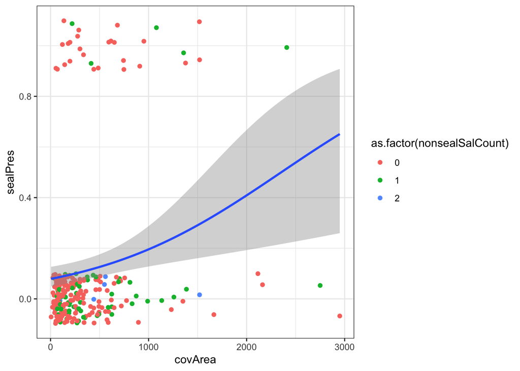

```r
pWS %>% ggplot(aes(x = covArea, y = sealPres)) +
  geom_jitter(aes(col = as.factor(nonsealSalCount)), height = .1) +
  #scale_color_manual(values = habCols) +
  stat_smooth(method = "glm", method.args = list(family = "binomial")) +
  theme_bw()
```

`roommate` is a categorical variable in which `roommate[roomate]` designates the presence of an additional salamander species or crayfish and `roommate[no roommate]` designates the absence of an additional salamander species or crayfish

```r
mic_4.2 = glmmTMB(sealPres ~ roommate * covArea + (1|StrmID), data = pWS, family = "binomial")
summary(mic_4.2)
```

```
##  Family: binomial  ( logit )
## Formula:          sealPres ~ roommate * covArea + (1 | StrmID)
## Data: pWS
##
##      AIC      BIC   logLik deviance df.resid
##    158.4    176.0    -74.2    148.4      243
##
## Random effects:
##
## Conditional model:
##  Groups Name        Variance Std.Dev.
##  StrmID (Intercept) 0.504    0.7099
## Number of obs: 248, groups:  StrmID, 7
##
## Conditional model:
##                            Estimate Std. Error z value Pr(>|z|)
## (Intercept)              -2.8595921  0.5046478  -5.667 1.46e-08 ***
## roommateroommate         -1.0320674  0.8427461  -1.225 0.220708
## covArea                   0.0031035  0.0008204   3.783 0.000155 ***
## roommateroommate:covArea -0.0018871  0.0010132  -1.863 0.062520 .
## ---
## Signif. codes:  0 '***' 0.001 '**' 0.01 '*' 0.05 '.' 0.1 ' ' 1
```

```r
AICc(mic_4.2)
```

```
## [1] 158.6455
```

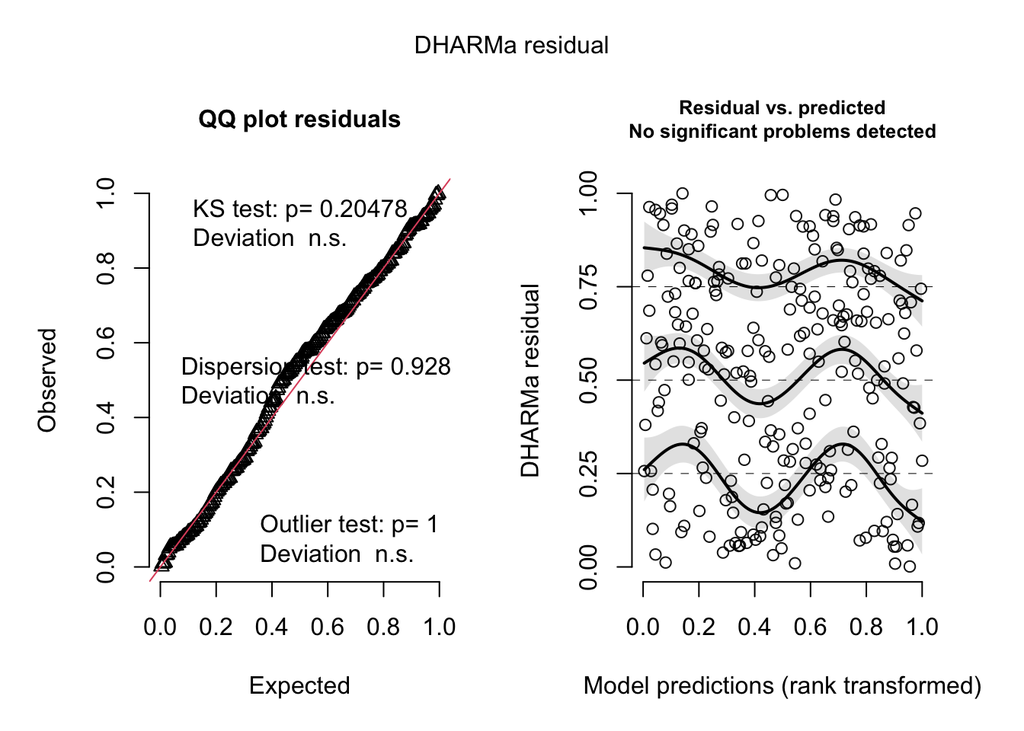

```r
resid_mic_4.2 = simulateResiduals(mic_4.2)
plot(resid_mic_4.2)
```

```r
tab_model(mic_4.2)
```

|  | sealPres |  |  |
| --- | --- | --- | --- |
| Predictors | Odds Ratios | CI | p |
| (Intercept) | 0.06 | 0.02 – 0.15 | **<0.001** |
| roommate [roommate] | 0.36 | 0.07 – 1.86 | 0.221 |
| covArea | 1.00 | 1.00 – 1.00 | **<0.001** |
| roommate [roommate] × covArea | 1.00 | 1.00 – 1.00 | 0.063 |
| Random Effects |  |  |  |
| σ<sup>2</sup> | 3.29 |  |  |
| τ<sub>00</sub> <sub>StrmID</sub> | 0.50 |  |  |
| ICC | 0.13 |  |  |
| N <sub>StrmID</sub> | 7 |  |  |
| Observations | 248 |  |  |
| Marginal R<sup>2</sup> / Conditional R<sup>2</sup> | 0.224 / 0.327 |  |  |

```r
performance::r2(mic_4.2)
```

```
## # R2 for Mixed Models
##
##   Conditional R2: 0.327
##      Marginal R2: 0.224
```

```r
confint(mic_4.2)
```

```
##                                   2.5 %        97.5 %     Estimate
## (Intercept)                -3.848683519 -1.870501e+00 -2.859592085
## roommateroommate           -2.683819434  6.196845e-01 -1.032067446
## covArea                     0.001495409  4.711496e-03  0.003103452
## roommateroommate:covArea   -0.003872873  9.865477e-05 -0.001887109
## Std.Dev.(Intercept)|StrmID  0.265113899  1.900959e+00  0.709908852
```

```r
fixef(mic_4.2)
```

```
##
## Conditional model:
##              (Intercept)          roommateroommate                   covArea
##                -2.859592                 -1.032067                  0.003103
## roommateroommate:covArea
##                -0.001887
```

```r
shapiro.test(residuals(mic_4.2))
```

```
##
##  Shapiro-Wilk normality test
##
## data:  residuals(mic_4.2)
## W = 0.66379, p-value < 2.2e-16
```

Obtaining the Odds Ratio estimates for this model

```r
#roommate estimate: -1.0320674
exp(-1.0320674)
```

```
## [1] 0.3562696
```

```r
#cov area estimate:  0.0031035

exp(0.0031035)
```

```
## [1] 1.003108
```

```r
#interaction estimate: -0.0018871
exp(-0.0018871 )
```

```
## [1] 0.9981147
```

### Additive model of roommate + cover area as predictors of seal presence

We can see that in this model, the presence of a roommate is significant. However, since the interaction model performs better than this additive one, we select that model

```r
mic_4.3 = glmmTMB(sealPres ~ roommate + covArea + (1|StrmID), data = pWS, family = "binomial")
summary(mic_4.3)
```

```
##  Family: binomial  ( logit )
## Formula:          sealPres ~ roommate + covArea + (1 | StrmID)
## Data: pWS
##
##      AIC      BIC   logLik deviance df.resid
##    160.4    174.5    -76.2    152.4      244
##
## Random effects:
##
## Conditional model:
##  Groups Name        Variance Std.Dev.
##  StrmID (Intercept) 0.5407   0.7353
## Number of obs: 248, groups:  StrmID, 7
##
## Conditional model:
##                    Estimate Std. Error z value Pr(>|z|)
## (Intercept)      -2.4226355  0.4423192  -5.477 4.32e-08 ***
## roommateroommate -2.2336704  0.7008405  -3.187 0.001437 **
## covArea           0.0018971  0.0005052   3.755 0.000173 ***
## ---
## Signif. codes:  0 '***' 0.001 '**' 0.01 '*' 0.05 '.' 0.1 ' ' 1
```

```r
AICc(mic_4.3)
```

```
## [1] 160.5927
```

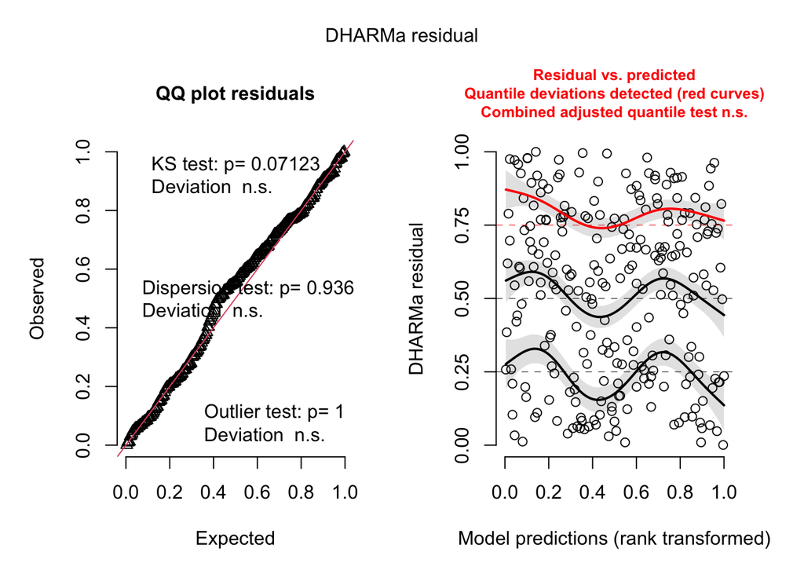

```r
resid_mic_4.3 = simulateResiduals(mic_4.3)
plot(resid_mic_4.3)
```

```r
tab_model(mic_4.3)
```

|  | sealPres |  |  |
| --- | --- | --- | --- |
| Predictors | Odds Ratios | CI | p |
| (Intercept) | 0.09 | 0.04 – 0.21 | **<0.001** |
| roommate [roommate] | 0.11 | 0.03 – 0.42 | **0.001** |
| covArea | 1.00 | 1.00 – 1.00 | **<0.001** |
| Random Effects |  |  |  |
| σ<sup>2</sup> | 3.29 |  |  |
| τ<sub>00</sub> <sub>StrmID</sub> | 0.54 |  |  |
| ICC | 0.14 |  |  |
| N <sub>StrmID</sub> | 7 |  |  |
| Observations | 248 |  |  |
| Marginal R<sup>2</sup> / Conditional R<sup>2</sup> | 0.275 / 0.377 |  |  |

```r
confint(mic_4.3)
```

```
##                                    2.5 %       97.5 %    Estimate
## (Intercept)                -3.2895651862 -1.555705733 -2.42263546
## roommateroommate           -3.6072924256 -0.860048337 -2.23367038
## covArea                     0.0009069967  0.002887224  0.00189711
## Std.Dev.(Intercept)|StrmID  0.2790377049  1.937781409  0.73533263
```

```r
fixef(mic_4.3)
```

```
##
## Conditional model:
##      (Intercept)  roommateroommate           covArea
##        -2.422635         -2.233670          0.001897
```

```r
exp(c( -2.422635, -2.233670, 0.001897))
```

```
## [1] 0.08868762 0.10713452 1.00189880
```

# FIG 6 LOGISTIC REGRESSION

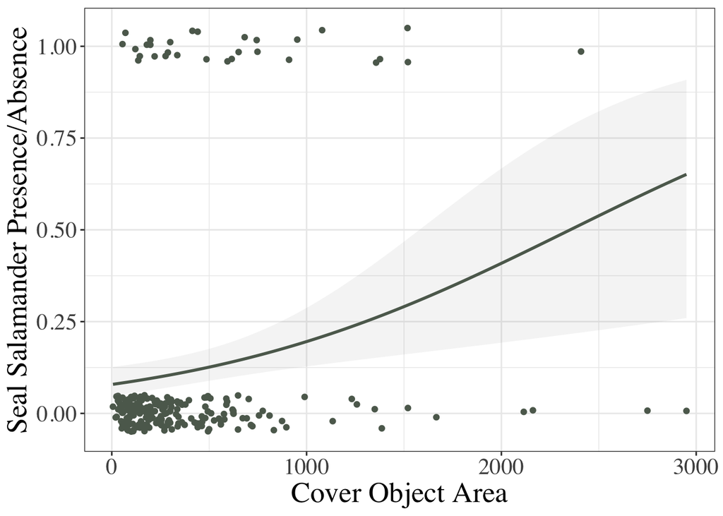

```r
communityFacet = pWS %>% ggplot(aes(x = covArea, y = sealPres

                                    )) +
  geom_jitter(height = .05, col = "#5D695C") +
  #scale_color_manual(values = habCols) +
  stat_smooth(method = "glm",
              col = "#5D695C",
              method.args = list(family = "binomial"),
              alpha = 0.1) +
  #labs(title = "Cover Object Area vs. Talladega Seal Salamander Presence/Absence") +
  xlab("Cover Object Area") +
  ylab("Seal Salamander Presence/Absence") +
  theme_bw() +
  #facet_wrap(~nonsealOccCountBinned, labeller = labeller(nonsealOccCountBinned = as_labeller(occupantLabs))) +
  theme(text = element_text(family = "Times",
    size = 20
    ),
        #legend.position = "none",
        #removing the ugly gray box behind the facet labels
        strip.background = element_rect(fill = "transparent", color = "black"),
        strip.placement = "outside",
        strip.text = element_text(color = "black"),
         panel.background = element_rect(fill='transparent'),
        plot.background = element_rect(fill='transparent', color=NA))

communityFacet
```

```r
# ggsave(plot = communityFacet, filename = "../outputs/Figs_HerpConBio/Fig6_LogisticCommunityFacet.pdf")
```

## Posthoc tests for best-performing microhabitat models

Comparison between the null model and the roommate x cov area interaction model

```r
anova(mic_4.2, mic_0, test = "Chisq")
```

```
## Data: pWS
## Models:
## ..2: sealPres ~ (1 | StrmID), zi=~0, disp=~1
## ..1: sealPres ~ roommate * covArea + (1 | StrmID), zi=~0, disp=~1
##     Df    AIC    BIC  logLik deviance Chisq Chi Df Pr(>Chisq)
## ..2  2 180.86 187.88 -88.429   176.86
## ..1  5 158.40 175.97 -74.199   148.40 28.46      3  2.908e-06 ***
## ---
## Signif. codes:  0 '***' 0.001 '**' 0.01 '*' 0.05 '.' 0.1 ' ' 1
```

Comparison between the roommate + cov area additive model and the roommate x cov area interaction model

```r
anova(mic_4.2, mic_4.3, test = "Chisq")
```

```
## Data: pWS
## Models:
## ..2: sealPres ~ roommate + covArea + (1 | StrmID), zi=~0, disp=~1
## ..1: sealPres ~ roommate * covArea + (1 | StrmID), zi=~0, disp=~1
##     Df    AIC    BIC  logLik deviance  Chisq Chi Df Pr(>Chisq)
## ..2  4 160.43 174.48 -76.214   152.43
## ..1  5 158.40 175.97 -74.199   148.40 4.0306      1    0.04468 *
## ---
## Signif. codes:  0 '***' 0.001 '**' 0.01 '*' 0.05 '.' 0.1 ' ' 1
```